# RITHEESH V_EDA_2

**Answer the following questions for the given US census data.**

Instructions:

- Drop duplicate records if present.
- Create visualizations where ever necessary.
- Submit your work in Jupyter Notebook and in HTML format with all the results.

**Data Dictionary:**

Unique values of features:

- `age`: continuous.
- `workclass`: Private, Self-emp-not-inc, Self-emp-inc, Federal-gov, Local-gov, State-gov, Without-pay, Never-worked.
- `fnlwgt`: continuous.
- `education`: Bachelors, Some-college, 11th, HS-grad, Prof-school, Assoc-acdm, Assoc-voc, 9th, 7th-8th, 12th, Masters, 1st-4th, 10th, Doctorate, 5th-6th, Preschool.
- `education-num`: continuous.
- `marital-status`: Married-civ-spouse, Divorced, Never-married, Separated, Widowed, Married-spouse-absent, Married-AF-spouse.
- `occupation`: Tech-support, Craft-repair, Other-service, Sales, Exec-managerial, Prof-specialty, Handlers-cleaners, Machine-op-inspct, Adm-clerical, Farming-fishing, Transport-moving, Priv-house-serv, Protective-serv, Armed-Forces.
- `relationship`: Wife, Own-child, Husband, Not-in-family, Other-relative, Unmarried.
- `race`: White, Asian-Pac-Islander, Amer-Indian-Eskimo, Other, Black.
- `sex`: Female, Male.
- `capital-gain`: continuous.
- `capital-loss`: continuous.
- `hours-per-week`: continuous.
- `native-country`: United-States, Cambodia, England, Puerto-Rico, Canada, Germany, Outlying-US(Guam-USVI-etc), India, Japan, Greece, South, China, Cuba, Iran, Honduras, Philippines, Italy, Poland, Jamaica, Vietnam, Mexico, Portugal, Ireland, France, Dominican-Republic, Laos, Ecuador, Taiwan, Haiti, Columbia, Hungary, Guatemala, Nicaragua, Scotland, Thailand, Yugoslavia, El-Salvador, Trinadad&Tobago, Peru, Hong, Holand-Netherlands.
- `salary`: >50K,<=50K

**1. How many men and women (*sex* feature) are represented in this dataset?**

**2. What is the average age (*age* feature) of women?**

**3. What is the proportion of German citizens (*native-country* feature)?**

**4-5. What are mean value and standard deviation of the age of those who recieve more than 50K per year (*salary* feature) and those who receive less than 50K per year?**

**6. Is it true that people who receive more than 50k have at least high school education? (*education - Bachelors, Prof-school, Assoc-acdm, Assoc-voc, Masters* or *Doctorate* feature)**

**7. Display statistics of age for each race (*race* feature) and each gender. Use *groupby()* and *describe()*. Find the maximum age of men of *Amer-Indian-Eskimo* race.**

**8. Among whom the proportion of those who earn a lot(>50K) is more: among married or single men (*marital-status* feature)? Consider married those who have a *marital-status* starting with *Married* (Married-civ-spouse, Married-spouse-absent or Married-AF-spouse), the rest are considered bachelors.**

**9. What is the maximum number of hours a person works per week (*hours-per-week* feature)? How many people work such a number of hours and what is the percentage of those who earn a lot among them?**

**10. Count the average time of work (*hours-per-week*) those who earning a little and a lot (*salary*) for each country (*native-country*).**

**11. Which workclass gets the highest salary?**

**12. Draw your own insights from the given data apart from the given list of questions.**

```python
import pandas as pd
import numpy as np
import matplotlib.pyplot as plt
import seaborn as sns
```

```python
df=pd.read_csv("D:\EDA\EDA&V-Assignment 2\EDA&V-Assignment 2\EDA_Assignment2.csv",na_values=['?','??'])
```

```python
df
```

|  | age | workclass | fnlwgt | education | education-num | marital-status | occupation | relationship | race | sex | capital-gain | capital-loss | hours-per-week | native-country | salary |
| --- | --- | --- | --- | --- | --- | --- | --- | --- | --- | --- | --- | --- | --- | --- | --- |
| 0 | 39 | State-gov | 77516 | Bachelors | 13 | Never-married | Adm-clerical | Not-in-family | White | Male | 2174 | 0 | 40 | United-States | <=50K |
| 1 | 50 | Self-emp-not-inc | 83311 | Bachelors | 13 | Married-civ-spouse | Exec-managerial | Husband | White | Male | 0 | 0 | 13 | United-States | <=50K |
| 2 | 38 | Private | 215646 | HS-grad | 9 | Divorced | Handlers-cleaners | Not-in-family | White | Male | 0 | 0 | 40 | United-States | <=50K |
| 3 | 53 | Private | 234721 | 11th | 7 | Married-civ-spouse | Handlers-cleaners | Husband | Black | Male | 0 | 0 | 40 | United-States | <=50K |
| 4 | 28 | Private | 338409 | Bachelors | 13 | Married-civ-spouse | Prof-specialty | Wife | Black | Female | 0 | 0 | 40 | Cuba | <=50K |
| ... | ... | ... | ... | ... | ... | ... | ... | ... | ... | ... | ... | ... | ... | ... | ... |
| 32556 | 27 | Private | 257302 | Assoc-acdm | 12 | Married-civ-spouse | Tech-support | Wife | White | Female | 0 | 0 | 38 | United-States | <=50K |
| 32557 | 40 | Private | 154374 | HS-grad | 9 | Married-civ-spouse | Machine-op-inspct | Husband | White | Male | 0 | 0 | 40 | United-States | >50K |
| 32558 | 58 | Private | 151910 | HS-grad | 9 | Widowed | Adm-clerical | Unmarried | White | Female | 0 | 0 | 40 | United-States | <=50K |
| 32559 | 22 | Private | 201490 | HS-grad | 9 | Never-married | Adm-clerical | Own-child | White | Male | 0 | 0 | 20 | United-States | <=50K |
| 32560 | 52 | Self-emp-inc | 287927 | HS-grad | 9 | Married-civ-spouse | Exec-managerial | Wife | White | Female | 15024 | 0 | 40 | United-States | >50K |

32561 rows × 15 columns

```python
df.columns
```

```
Index(['age', 'workclass', 'fnlwgt', 'education', 'education-num',
       'marital-status', 'occupation', 'relationship', 'race', 'sex',
       'capital-gain', 'capital-loss', 'hours-per-week', 'native-country',
       'salary'],
      dtype='object')
```

```python
df.isnull().sum()
```

```
age                  0
workclass         1836
fnlwgt               0
education            0
education-num        0
marital-status       0
occupation        1843
relationship         0
race                 0
sex                  0
capital-gain         0
capital-loss         0
hours-per-week       0
native-country     583
salary               0
dtype: int64
```

```python
df.isnull().sum()/df.shape[0]*100
```

```
age               0.000000
workclass         5.638647
fnlwgt            0.000000
education         0.000000
education-num     0.000000
marital-status    0.000000
occupation        5.660146
relationship      0.000000
race              0.000000
sex               0.000000
capital-gain      0.000000
capital-loss      0.000000
hours-per-week    0.000000
native-country    1.790486
salary            0.000000
dtype: float64
```

- from the given data we have null values in **workclass** , **occupation** and **native-country**
- The three columns are **categorical variable** hence to get rid of null values we are replacing it with **mode**

```python
df['workclass']=df["workclass"].fillna(df['workclass'].mode()[0])
df['occupation']=df["occupation"].fillna(df['occupation'].mode()[0])
df['native-country']=df["native-country"].fillna(df['native-country'].mode()[0])
```

```python
df.isnull().sum()/df.shape[0]*100
```

```
age               0.0
workclass         0.0
fnlwgt            0.0
education         0.0
education-num     0.0
marital-status    0.0
occupation        0.0
relationship      0.0
race              0.0
sex               0.0
capital-gain      0.0
capital-loss      0.0
hours-per-week    0.0
native-country    0.0
salary            0.0
dtype: float64
```

```python
df.duplicated().value_counts()
```

```
False    32537
True        24
dtype: int64
```

```python
df.drop_duplicates(inplace=True) #dropping duplicates
```

###### 1. How many men and women (sex feature) are represented in this dataset?

```python
df["sex"].value_counts()
```

```
Male      21775
Female    10762
Name: sex, dtype: int64
```

###### 2. What is the average age (age feature) of women?

```python
df.groupby('sex')['age'].mean()
```

```
sex
Female    36.864709
Male      39.436051
Name: age, dtype: float64
```

###### 3. What is the proportion of German citizens (native-country feature)?

```python
(df["native-country"]=="Germany").sum()/df.shape[0]*100
```

```
0.4210591019454774
```

###### 4-5. What are mean value and standard deviation of the age of those who recieve more than 50K per year (salary feature) and those who receive less than 50K per year?

```python
age1=df[df['salary']=='>50K']['age']
age2=df[df['salary']=='<=50K']['age']
```

```python
print(age1.mean())
print(age1.std())
print(age2.mean())
print(age2.std())
```

```
44.25092486286516
10.52010208815647
36.78739169163495
14.017334627959187
```

###### 6. Is it true that people who receive more than 50k have at least high school education? (education - Bachelors, Prof-school, Assoc-acdm, Assoc-voc, Masters or Doctorate feature)

```python
df[df['salary']=='>50K']['education'].unique()
```

```
array(['HS-grad', 'Masters', 'Bachelors', 'Some-college', 'Assoc-voc',
       'Doctorate', 'Prof-school', 'Assoc-acdm', '7th-8th', '12th',
       '10th', '11th', '9th', '5th-6th', '1st-4th'], dtype=object)
```

```python
df['education'].value_counts()
```

```
HS-grad         10494
Some-college     7282
Bachelors        5353
Masters          1722
Assoc-voc        1382
11th             1175
Assoc-acdm       1067
10th              933
7th-8th           645
Prof-school       576
9th               514
12th              433
Doctorate         413
5th-6th           332
1st-4th           166
Preschool          50
Name: education, dtype: int64
```

###### 7. Display statistics of age for each race (race feature) and each gender. Use groupby() and describe(). Find the maximum age of men of Amer-Indian-Eskimo race.

```python
df.groupby(['race','sex']).agg({'age':'describe'})
```

| race | sex | age count | age mean | age std | age min | age 25% | age 50% | age 75% | age max |
| --- | --- | --- | --- | --- | --- | --- | --- | --- | --- |
| Amer-Indian-Eskimo | Female | 119.0 | 37.117647 | 13.114991 | 17.0 | 27.0 | 36.0 | 46.00 | 80.0 |
|  | Male | 192.0 | 37.208333 | 12.049563 | 17.0 | 28.0 | 35.0 | 45.00 | 82.0 |
| Asian-Pac-Islander | Female | 346.0 | 35.089595 | 12.300845 | 17.0 | 25.0 | 33.0 | 43.75 | 75.0 |
|  | Male | 692.0 | 39.000000 | 12.746669 | 18.0 | 29.0 | 37.0 | 46.00 | 90.0 |
| Black | Female | 1555.0 | 37.854019 | 12.637197 | 17.0 | 28.0 | 37.0 | 46.00 | 90.0 |
|  | Male | 1567.0 | 37.699426 | 12.880714 | 17.0 | 27.0 | 36.0 | 46.00 | 90.0 |
| Other | Female | 109.0 | 31.678899 | 11.631599 | 17.0 | 23.0 | 29.0 | 39.00 | 74.0 |
|  | Male | 162.0 | 34.654321 | 11.355531 | 17.0 | 26.0 | 32.0 | 42.00 | 77.0 |
| White | Female | 8633.0 | 36.819646 | 14.331045 | 17.0 | 25.0 | 35.0 | 46.00 | 90.0 |
|  | Male | 19162.0 | 39.656560 | 13.436249 | 17.0 | 29.0 | 38.0 | 49.00 | 90.0 |

###### 8. Among whom the proportion of those who earn a lot(>50K) is more: among married or single men (marital-status feature)? Consider married those who have a marital-status starting with Married (Married-civ-spouse, Married-spouse-absent or Married-AF-spouse), the rest are considered bachelors.

```python
# married men
df[(df["sex"] == "Male") & (df["marital-status"].str.startswith("Married"))]["salary"].value_counts(normalize=True)
```

```
<=50K    0.559438
>50K     0.440562
Name: salary, dtype: float64
```

```python
# single men
df[(df["sex"] == "Male") & (df["marital-status"].str.startswith("Married"))]["salary"].value_counts(normalize=True)
```

```
<=50K    0.559438
>50K     0.440562
Name: salary, dtype: float64
```

###### 9. What is the maximum number of hours a person works per week (hours-per-week feature)? How many people work such a number of hours and what is the percentage of those who earn a lot among them?

```python
max_hours=df["hours-per-week"].max()
print('max time of a person {0} hours'.format(max_hours))
```

```
max time of a person 99 hours
```

```python
max_work_people=df[df['hours-per-week']==max_hours].shape[0]
print('The people who work hard are {0}'.format(max_work_people))
```

```
The people who work hard are 85
```

```python
df[(df['hours-per-week']==max_hours)&(df['salary']=='>50K')].shape[0]
```

```
25
```

```python
rich_people=round((df[(df['hours-per-week']==max_hours)&(df['salary']=='>50K')].shape[0]/max_work_people)*100,0)
print("The proportion of rich people is {0}".format(rich_people))
```

```
The proportion of rich people is 29.0
```

###### 10. Count the average time of work (hours-per-week) those who earning a little and a lot (salary) for each country (native-country).

```python
df.groupby(['native-country','salary']).agg({'hours-per-week':'mean'})
```

| native-country | salary | hours-per-week |
| --- | --- | --- |
| Cambodia | <=50K | 41.416667 |
|  | >50K | 40.000000 |
| Canada | <=50K | 37.914634 |
|  | >50K | 45.641026 |
| China | <=50K | 37.381818 |
| ... | ... | ... |
| United-States | >50K | 45.506630 |
| Vietnam | <=50K | 37.193548 |
|  | >50K | 39.200000 |
| Yugoslavia | <=50K | 41.600000 |
|  | >50K | 49.500000 |

80 rows × 1 columns

###### 11. Which workclass gets the highest salary?

```python
df.groupby(df[df['salary']=='>50K']['salary'])['workclass'].value_counts()
```

```
salary  workclass
>50K    Private             5152
        Self-emp-not-inc     724
        Self-emp-inc         622
        Local-gov            617
        Federal-gov          371
        State-gov            353
Name: workclass, dtype: int64
```

###### 12. Draw your own insights from the given data apart from the given list of questions.

```python
data=pd.read_csv("D:\EDA\EDA&V-Assignment 2\EDA&V-Assignment 2\EDA_Assignment2.csv",na_values='?')
```

```python
df1=df.copy()
```

```python
import missingno as ms
```

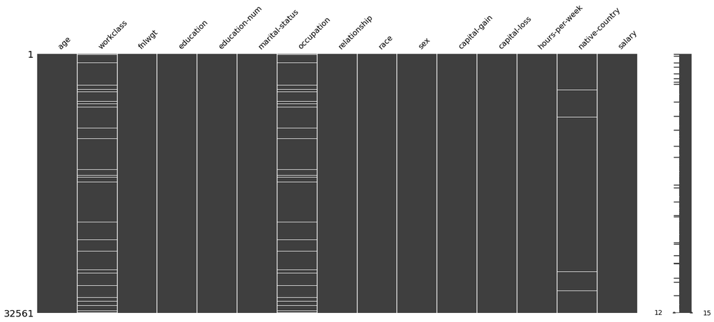

```python
ms.matrix(data)
```

```python
#from the above chart using missingo we found that there are some missing values in workclass occupation and native-country
```

#### outliers

###### *age* column

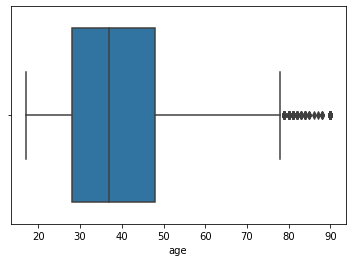

```python
#Boxplot
sns.boxplot(x='age',data=df)
```

```python
#Z score
upper = df1['age'].mean() + (3*df1['age'].std())
lower = df1['age'].mean() - (3*df1['age'].std())
df1[(df1['age']> upper) | (df1['age']<lower)].shape[0]
```

```
120
```

```python
upper=df['age'].quantile(0.95)
lower=df['age'].quantile(0.01)
```

```python
df1['age']=np.clip(df['age'],lower,upper)
```

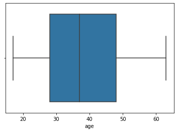

```python
sns.boxplot(x='age',data=df1)
```

###### fnlwgt column

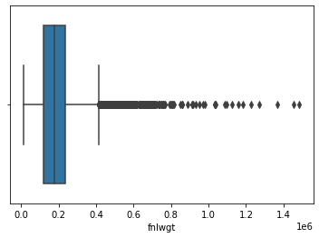

```python
#Boxplot
sns.boxplot(x='fnlwgt',data=df)
```

```python
#Z score
upper = df1['fnlwgt'].mean() + (3*df1['fnlwgt'].std())
lower = df1['fnlwgt'].mean() - (3*df1['fnlwgt'].std())
df1[(df1['fnlwgt']> upper) | (df1['fnlwgt']<lower)].shape[0]
```

```
346
```

```python
upper=df['fnlwgt'].quantile(0.95)
lower=df['fnlwgt'].quantile(0.01)
```

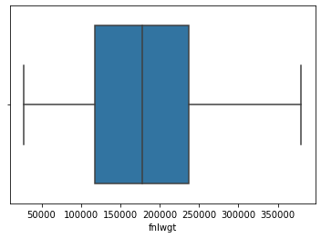

```python
df1['fnlwgt']=np.clip(df1['fnlwgt'],lower,upper)
sns.boxplot(x='fnlwgt',data=df1)
```

###### education-num column

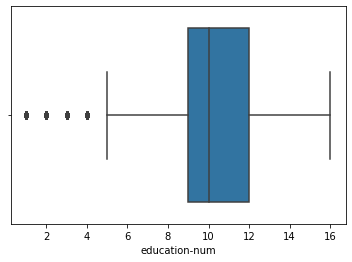

```python
#Boxplot
sns.boxplot(x='education-num',data=df)
```

```python
#Z score
upper = df1['education-num'].mean() + (3*df1['education-num'].std())
lower = df1['education-num'].mean() - (3*df1['education-num'].std())
df1[(df1['education-num']> upper) | (df1['education-num']<lower)].shape[0]
```

```
216
```

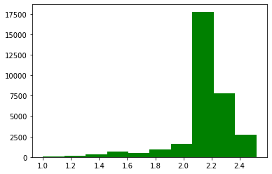

```python
df1['education-num-log']=np.log(df1['education-num'])
df1['education-num-sqrt']=np.sqrt(df1['education-num'])
df1['education-num-cbrt']=np.cbrt(df1['education-num'])

print(plt.hist(df1['education-num-cbrt'],color='g'))
```

###### capital-gain column

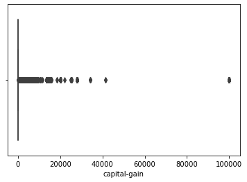

```python
#Boxplot
sns.boxplot(x='capital-gain',data=df)
```

```python
#Z score
upper = df1['capital-gain'].mean() + (3*df1['capital-gain'].std())
lower = df1['capital-gain'].mean() - (3*df1['capital-gain'].std())
df1[(df1['capital-gain']> upper) | (df1['capital-gain']<lower)].shape[0]
```

```
215
```

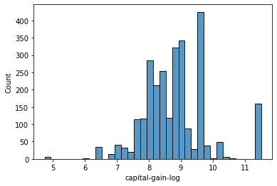

```python
df1['capital-gain-log']=np.log(df['capital-gain'])
df1['capital-gain-sqrt']=np.sqrt(df['capital-gain'])
df1['capital-gain-cbrt']=np.cbrt(df['capital-gain'])
sns.histplot(x='capital-gain-log',data=df1)
```

```python
df.columns
```

```
Index(['age', 'workclass', 'fnlwgt', 'education', 'education-num',
       'marital-status', 'occupation', 'relationship', 'race', 'sex',
       'capital-gain', 'capital-loss', 'hours-per-week', 'native-country',
       'salary'],
      dtype='object')
```

```python
data.corr()
```

|  | age | fnlwgt | education-num | capital-gain | capital-loss | hours-per-week |
| --- | --- | --- | --- | --- | --- | --- |
| age | 1.000000 | -0.076646 | 0.036527 | 0.077674 | 0.057775 | 0.068756 |
| fnlwgt | -0.076646 | 1.000000 | -0.043195 | 0.000432 | -0.010252 | -0.018768 |
| education-num | 0.036527 | -0.043195 | 1.000000 | 0.122630 | 0.079923 | 0.148123 |
| capital-gain | 0.077674 | 0.000432 | 0.122630 | 1.000000 | -0.031615 | 0.078409 |
| capital-loss | 0.057775 | -0.010252 | 0.079923 | -0.031615 | 1.000000 | 0.054256 |
| hours-per-week | 0.068756 | -0.018768 | 0.148123 | 0.078409 | 0.054256 | 1.000000 |

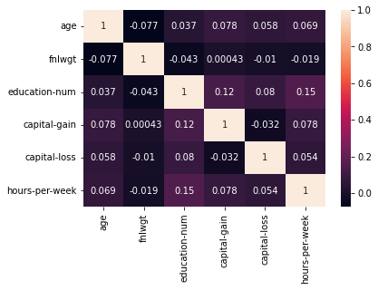

```python
sns.heatmap(data.corr(),annot=True)
```

From the given data we observe that weak positive correlation exists between most of the columns in our data

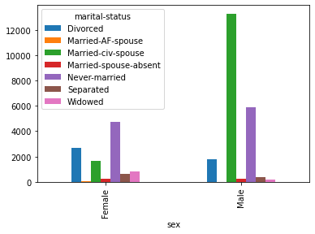

```python
pd.crosstab(df['sex'],df['marital-status']).plot(kind='bar')
```

```python
pd.crosstab(df['sex'],df['hours-per-week'],margins=True)
```

| hours-per-week sex | 1 | 2 | 3 | 4 | 5 | 6 | 7 | 8 | 9 | 10 | ... | 90 | 91 | 92 | 94 | 95 | 96 | 97 | 98 | 99 | All |
| --- | --- | --- | --- | --- | --- | --- | --- | --- | --- | --- | --- | --- | --- | --- | --- | --- | --- | --- | --- | --- | --- |
| Female | 10 | 14 | 14 | 32 | 32 | 31 | 14 | 78 | 10 | 127 | ... | 4 | 0 | 0 | 0 | 0 | 0 | 0 | 0 | 19 | 10762 |
| Male | 10 | 18 | 25 | 22 | 28 | 33 | 12 | 67 | 8 | 148 | ... | 25 | 3 | 1 | 1 | 2 | 5 | 2 | 11 | 66 | 21775 |
| All | 20 | 32 | 39 | 54 | 60 | 64 | 26 | 145 | 18 | 275 | ... | 29 | 3 | 1 | 1 | 2 | 5 | 2 | 11 | 85 | 32537 |

3 rows × 95 columns

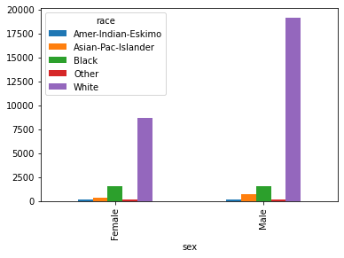

```python
pd.crosstab(df['sex'],df['race']).plot(kind='bar')
```

## Inference

- overall male population work more compared to the females
- most of the populaton from the data are white people
- most male marital-status is married-civ-spouce
- most female marital-status is never-married